# Flow Matching Predictive Control with Constraints

Master’s Thesis in Robotics, Cognition, Intelligence · Defence

Author: Liming Liu

Examiner: Prof. Dr.-Ing. habil. Alois Knoll

Supervisor: Erdi Sayar

Technische Universität München · School of Computation, Information and Technology — Informatics

## A generative planner kept safe at inference time, without retraining

The constraints are declared at deployment and imposed on every plan as it is generated, so when an obstacle is added or moved, the constraint set changes and the trained model stays.

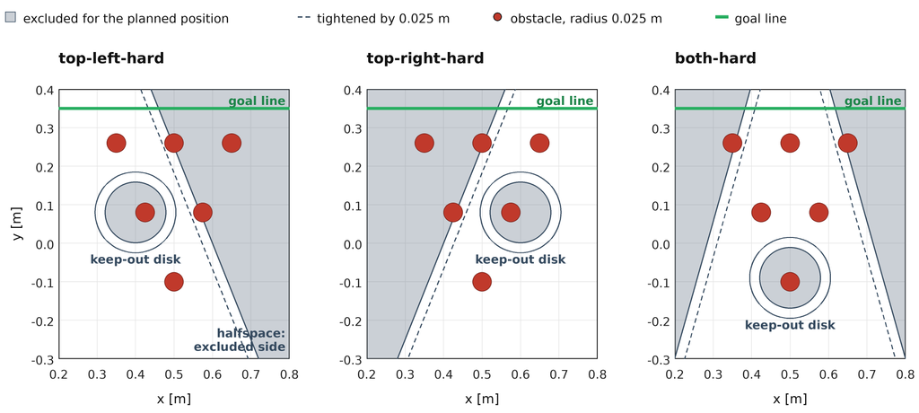

The three constraint geometries of D3IL-avoiding, introduced at test time. Thesis Fig. 5.3

- **The price.** DPCC does this with a diffusion model and a projection at every denoising step, at the price of a long sampling loop run at every control step.
- **The aim.** This thesis asks how to pay less for the same safety, with a flow-matching model in place of the diffusion model.

## Receding horizon: plan eight steps, execute the first, plan again

[figure not shown]

## One control step, block by block, on D3IL-avoiding

[figure not shown]

Illustration, not thesis data

**1 · Observation** — the commanded and the measured position, .

**2 · Candidates** — plans, each drawn from independent noise.

**3 · Sampling with projection** — the model’s steps; the projection constrains the iterates or the predicted endpoint.

**4 · Candidate selection** — temporal consistency: the candidate closest to the previous plan.

**5 · First increment → setpoint** — .

**6 · Tracking controller** — differential IK → joint PD moves the arm towards the setpoint; the next observation starts the next step.

## The network reads a plan as an 8 × d signal

[figure not shown]

The plan tensor of D3IL-avoiding, . Dark: the known current state, imposed by inpainting and masked in the loss.

Environment

Plan in / out

State anchor

D3IL-avoiding

D3IL-aligning

UAV-corridor, UAV-s-curve

D3IL-aligning adds two RGB views, , encoded to . UAV-pillars flies the D3IL-avoiding models.

- A temporal U-Net: convolution along time, channel widths , three stride-two stages () with skip connections.
- Conditioning is a per-channel bias in every block: the time embedding of , plus for Analytic-MeanFM and CI-MeanFM, plus the image latent on D3IL-aligning.
- The output has the plan’s shape: , , or the baseline’s noise .

## Diffusion: predict the noise, remove it step by step

[figure not shown]

- A network is trained to predict the noise added at each step; generation starts from pure noise and removes it step by step.
- The number of steps is tied to the training schedule: fixed when training ends ( in DPCC); fewer steps need a different sampler.
- The sampler adds noise at every step but the last: plans for the same observation can differ.

Illustration, not thesis data

## Flow matching: a velocity field transports noise to data

[figure not shown]

Illustration, not thesis data

|  | learns | steps | sampling |
| --- | --- | --- | --- |
| Diffusion (DPCC’s sampler) | the noise | fixed at training | adds noise |
| FM | velocity | chosen at deployment | deterministic given the noise |
| Analytic-MeanFM, CI-MeanFM | average velocity | chosen at deployment | deterministic given the noise |

- Straight per-sample paths average into a curved field, and coarse steps along a curved field are inaccurate.
- One evaluation of an accurate average velocity covers the whole interval.

## Three objectives inside the same constrained controller

FM  
instantaneous-velocity matching

Analytic-MeanFM  
analytic average-velocity matching

CI-MeanFM  
consistency-interpolated average-velocity matching

; : stop-gradient. Backbone, projection, data and evaluation protocol are kept; the number of network evaluations becomes a choice made at deployment. Both average-velocity objectives train half of their samples at , where both targets are , and an auxiliary instantaneous head. Each objective trains with its own converged recipe (thesis Table 5.8): the results are those of the trained configurations.

|  | Analytic-MeanFM | CI-MeanFM |
| --- | --- | --- |
| the target | the identity’s derivative, taken exactly (a JVP) | whole interval = step + rest; α interpolates |
| loss weight, | 1 |  |
| curriculum | none | from 1 by a sigmoid, held at 0.2 |

## Analytic: the target comes from differentiating the average-velocity identity

[figure not shown]

Illustration, not thesis data

One path, : generation time across, one plan coordinate up, from to .

**Average velocity:** the displacement over the interval, divided by its length. Here 1, while the velocity at the start is 0.4.

**Keep the destination, move the start:** the destination does not change, so its derivative is zero.

**Check:** ; the derivative term closes the gap. It moves all three inputs at once:

**The analytic target** puts the network in place of the unknown field, takes its exact derivative and freezes the result:

## Consistency-interpolated: a finite step replaces the derivative, and α sets its length

[figure not shown]

Illustration, not thesis data: how the target is built, not how well it trains

Same path. The target is built in two parts: a straight step with , then the network’s own prediction for the rest, frozen:

**α = 1:** one straight step over the whole interval. The target is , the instantaneous velocity.

**α = 0.5:** a step of 0.3, then the prediction from the shifted point: 0.85.

**α = 0.2:** 0.976. In training, α follows a sigmoid schedule from 1 and is held at 0.2.

**α → 0:** the target tends to the network’s current output, and its residual divided by α to the analytic residual: on this exact field, 1 and 0. At exactly α = 0 the implementation switches to the JVP target.

**Consistency:** the prediction for the whole interval must agree with a step plus the network’s own prediction for the rest. **Interpolated:** α moves the target between the instantaneous velocity and that prediction.

## The projection: the closest plan that satisfies the constraints

[figure not shown]

Illustration, not thesis data; the dynamics rows are not drawn

- subject to the **dynamics rows** of the first-order model, the **bounds and halfspaces**, and one **quadratic keep-out inequality** per horizon step and obstacle. The first block is fixed at the measured state.
- The constraints are **tightened** by a margin for the model mismatch.
- **Goal-independent:** its objective is proximity to the proposed plan. Success is not its objective.
- A non-linear program, since the keep-out rows are non-convex, solved by SLSQP. Its cost is what the cumulative-cost selection rule sums.
- **A local numerical solve:** at most 1000 iterations; it can return its last iterate, so feasibility of the output is not guaranteed. Violations are counted on the executed trajectories.

## Two ways to put the projection into sampling

**Per-step projection (DPCC)**: project the current iterate

iterate  
→ model step  
→ no prediction  
of the final plan → project the iterate  
→ no pull-back:  
the projection is kept → next iterate

**Guidance.** A feasibility likelihood around , expanded to first order, gives a step to the projection; in the diffusion sampler . Early in sampling the iterate is still far from the data, so the keep-out rows are evaluated on positions the sampler has not yet produced.

**Endpoint projection (HardFlow)**: project the predicted final plan

iterate  
→ model step  
→ predict the final plan  
→ project the prediction  
→ pull back  
damped by → next iterate

**Optimal control.** Steer the learned flow with the least control effort so that only the final sample is feasible: s.t. , . Solved one sampling step at a time, on the predicted final plan, so that the constraint set is not distorted by the network.

Both solve the same program on the same feasible set with the same solver, from a threshold step to the end of sampling. The terminal cost is zero here, so the HardFlow solve is the projection of the predicted plan.

## Endpoint projection constrains a trajectory from the first step on

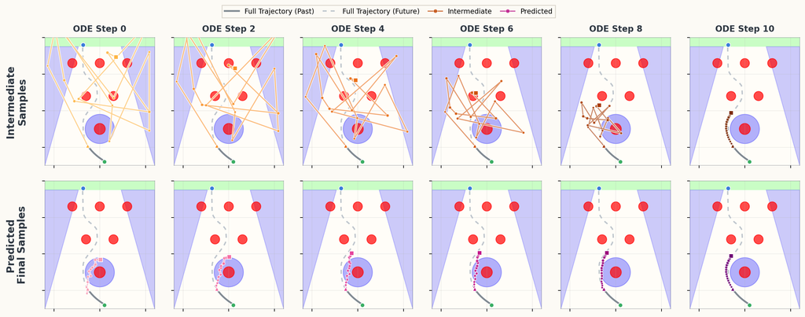

- **Upper row:** the sample the solver holds, far from a trajectory until the last steps. Per-step projection poses its program on such an iterate.
- **Lower row:** its predicted final sample, a trajectory from the first step on: the point endpoint projection constrains.

Reproduced unaltered from Li, Alim and Azizan, HardFlow (arXiv:2511.08425v3), Fig. 11, CC BY 4.0; their task and run.

## Endpoint projection, one guided step, on a plan

[figure not shown]

Illustration, not thesis data

The first guided step, of . The iterate is still noisy.

**1 · Step** the sampler once, unguided

**2 · Predict** the final plan, in closed form

**3 · Project** the predicted plan

**4 · Pull back** the correction, damped by

Per-step projection would project the noisy iterate itself, .

## Endpoint projection guides only where the budget leaves a step before the last

[figure not shown]

for : the active steps are the last , and the terminal one does not guide.

## Research questions

- **RQ1 — Generative model.** Can the flow-based models reach the diffusion baseline’s task success and constraint satisfaction with fewer sampling steps and less planning time per control step?
- **RQ2 — Constraints.** Does endpoint projection reach the goal with fewer constraint violations, fewer control steps or less computation than the per-step projection of DPCC?
- **RQ3 — Transfer.** Do the answers to RQ1 and RQ2 hold when the observation becomes camera images, when the task requires aligning an object through contact, and when the platform is a quadrotor?

Three steps: **D3IL-avoiding**, the benchmark of DPCC unchanged → **D3IL-aligning**, observed through cameras → **quadrotor**, three scenes.

## D3IL-avoiding: the benchmark of DPCC, unchanged

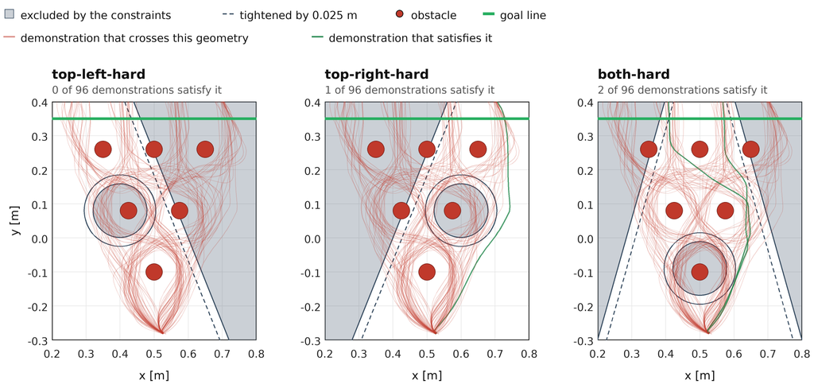

The 96 demonstrations against the three geometries. Thesis Fig. 5.9

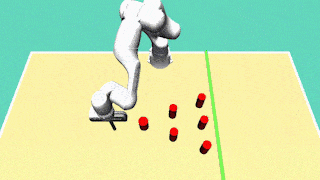

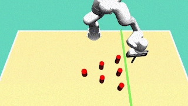

Start pose, goal passed. Thesis Fig. 5.2

- The Panda manipulator moves its end effector across a field of six obstacles to a goal line.
- Three constraint geometries, introduced at test time: 0, 1 and 2 of the 96 demonstrations satisfy the tightened sets. The same environment, data, projection and protocol as DPCC: five training seeds × two episodes per geometry.

## On the benchmark of DPCC, the average-velocity models reach the goal in the fewest control steps, at a thirtieth of its diffusion model’s time

[figure not shown]

Thesis numbers, at the protocol of DPCC: planner time per action against control steps; S&C = success with constraint satisfaction; each model under its selected rule; the diffusion points are the reproduced baseline.

## The time a projection takes depends on how far from feasible the plan it receives is

Analytic-MeanFM ·

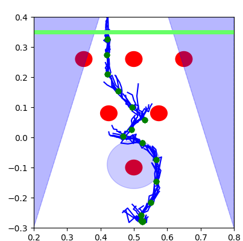

6.0 violating steps

CI-MeanFM ·

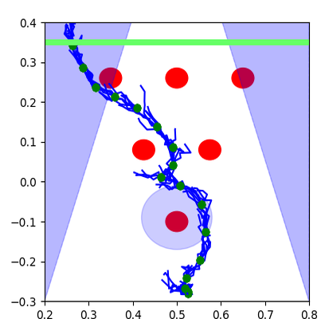

FM ·

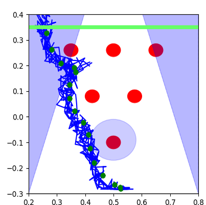

Diffusion ·

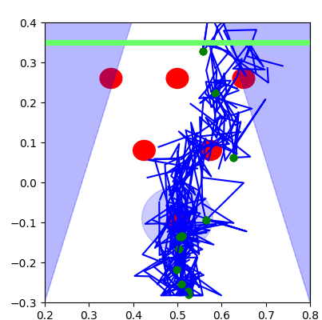

28.0 violating steps

Diffusion · , trained budget

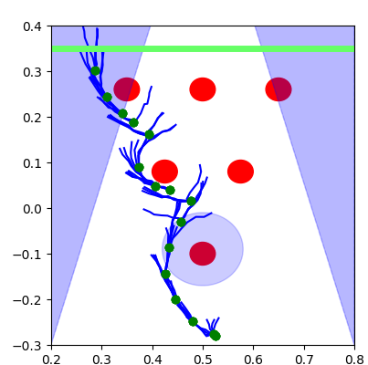

18.5 violating steps

Plans without projection, every fourth control step, all four candidates; both-hard, one training seed; violating steps per episode in this cell. The executed path is not drawn.

- At one evaluation Analytic-MeanFM’s successive plans form a narrow ribbon; the diffusion baseline’s plans jump across the workspace from one control step to the next.
- At its own twenty steps the baseline draws a single tight bundle, the upper half of which lies inside the left halfspace.

## D3IL-aligning: the robot observes two camera views

Expert demonstration (MuJoCo), the two camera views

- The manipulator pushes a box into a target pose; a context is an initial box pose and a target pose.
- No box or target pose in the observation vector: the policy must find the box in two RGB streams, a front and an in-hand view.
- The network gets a visual encoder; the projection gets the dynamics rows and this task’s constraint set.
- **The constraints**, right: a keep-out disk between box and target and a halfspace at the far corner. The straight push crosses the disk in 106 of 120 recorded contexts, 119 once the region is tightened.

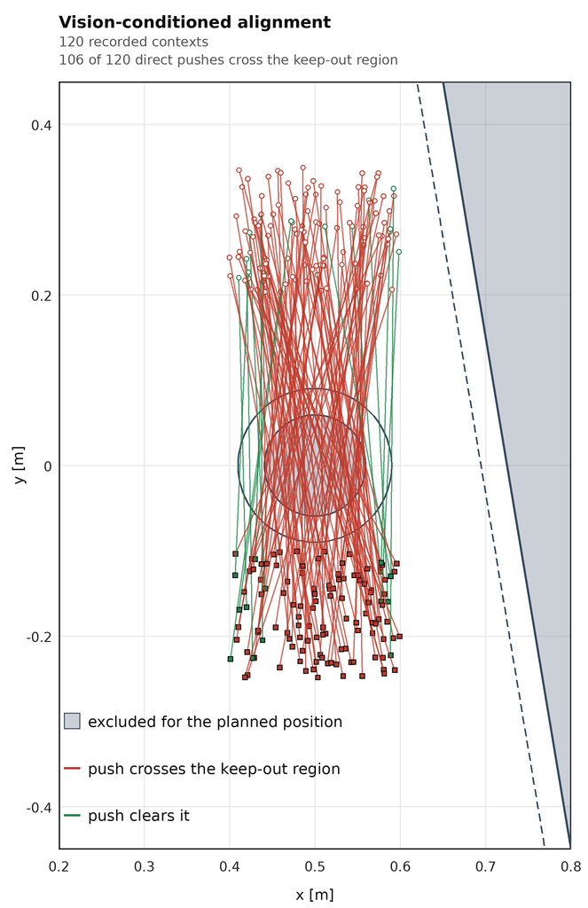

The constraint set and the 120 recorded contexts. Thesis Fig. 5.10

## D3IL-aligning: the images enter the network as one latent of 128 numbers

[figure not shown]

- The observation is two RGB views plus a 6-D state, the commanded and measured end-effector positions; the box and its target pose are only in the images.
- The backbone never sees an image: the latent is the interface between perception and generation; the encoders train end to end with it.

Frames: thesis Fig. 5.5

## On D3IL-aligning the dominance repeats where the task separates the models

[figure not shown]

Thesis numbers: distance closed without projection at , ten training-set contexts, one seed; median final against mean initial distance.

- At two evaluations, at a seventh to a tenth of their cost, Analytic-MeanFM’s reduction is already two fifths.
- CI-MeanFM does not improve with the budget below a hundred evaluations.

## At the budget this task needs, endpoint projection is the better projector on the constraint

[figure not shown]

Thesis numbers: contexts free of violations after projection, , random selection; every of 10 includes the guarded context.

- Endpoint projection keeps more contexts violation-free than per-step projection in seven of nine comparisons.
- The constraint is paid for in distance: no context ends within the 1.8 cm of the task’s own test, projected or not.

Endpoint: 20 integration steps + 3 lookaheads (NFE 23); for the average-velocity models both evaluations query the zero-interval head. Times are measured.

## Quadrotor: three scenes that ask three different questions

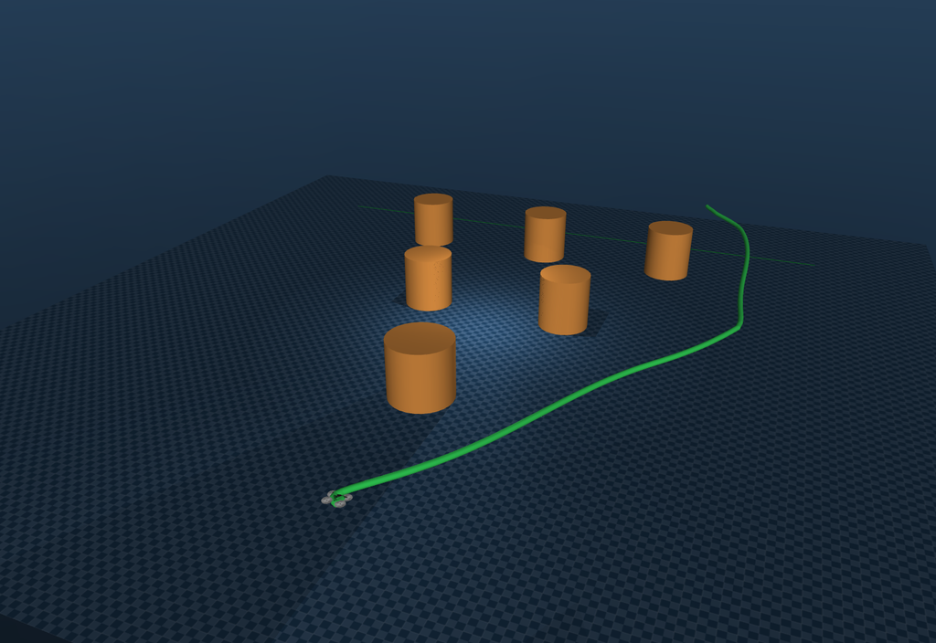

**UAV-pillars**  
D3IL-avoiding flown by the quadrotor

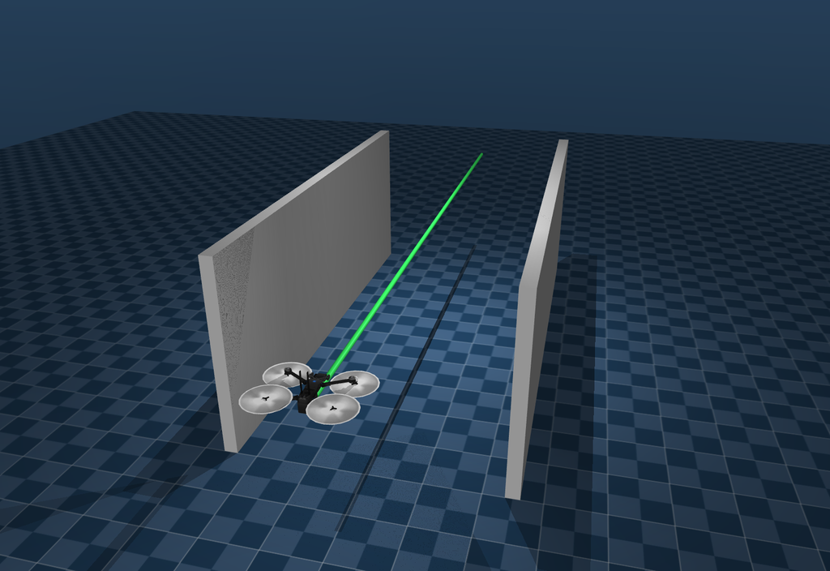

**UAV-corridor**  
constraints that leave the horizontal plane

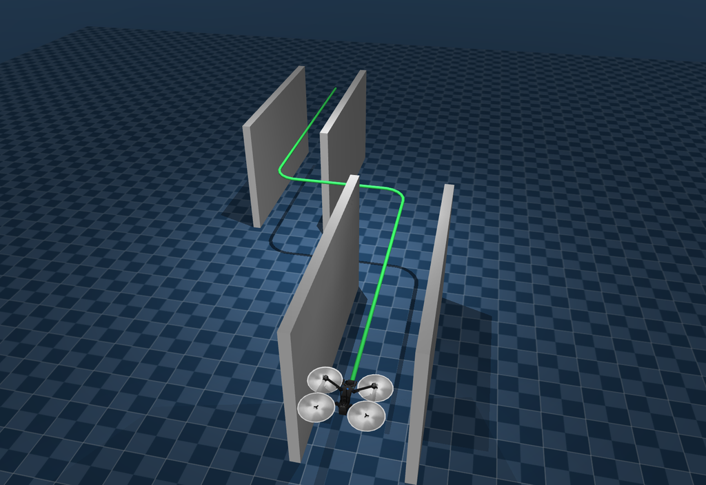

**UAV-s-curve**  
two sharp turns for the tracking controller

Skydio X2 of MuJoCo Menagerie, commanded through its rotor thrusts by a cascaded geometric tracking controller.

## The quadrotor keeps the planning side and changes the control problem

D3IL · manipulator

observation  
→ plan  
→ projection  
Euler rows → selection → setpoint  
→ differential IK  
→ joint PD

UAV · quadrotor

observation  
→ plan  
→ projection  
Euler rows → selection → setpoint  
→ geometric cascade  
→ rotor thrusts

**Stays: the planning side**

- plans of eight position increments; the same setpoint recursion
- the projection with its first-order dynamics rows ()
- the four objectives and their training targets; UAV-pillars flies the D3IL-avoiding models unchanged

**Changes: the control problem**

- an underactuated, open-loop unstable plant: four rotor thrusts for six degrees of freedom
- the tracking controller: cascaded geometric (MuJoCo MPC in the controller comparison)
- constraints that leave the horizontal plane (UAV-corridor); generated demonstrations

## UAV-pillars: the result of D3IL-avoiding holds when its plans are flown

[figure not shown]

Thesis numbers: success within the constraints at the operating points, arm against quadrotor.

- After projection no flight violates the declared constraints; the vehicle tracks more closely than the arm.
- Every failure is a collision with one of the five pillars the constraint sets leave out.

## UAV-corridor: two test-time constraints leave the horizontal plane

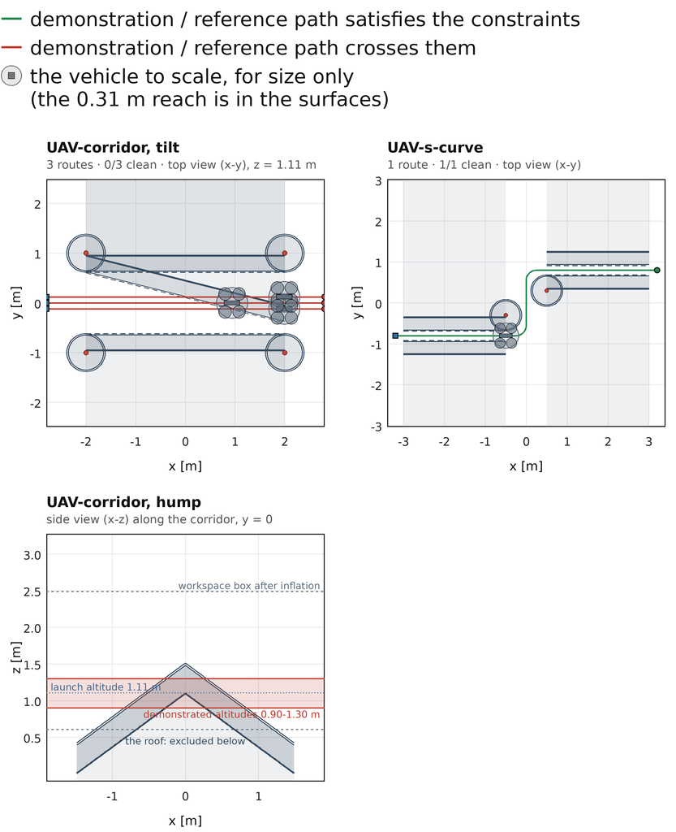

Left: UAV-corridor, the tilt from above and the hump from the side; right: UAV-s-curve. Thesis Fig. 5.11

- **Tilt:** one plane slopes by 14° across the corridor and leans 60° from the vertical, so it pushes the vehicle sideways and downward at once. At the launch altitude a sideways move alone does not clear it.
- **Hump:** a roof in the vertical plane, rising to 1.10 m at the middle of the corridor, which the vehicle must climb over.
- **Test-time only:** the models are trained on a narrower, level corridor. The three demonstrated lanes clear both walls, but every one crosses the tilt and passes under the hump.
- Each surface carries the rotor reach of 0.31 m; the two constraints are evaluated separately.

## UAV-corridor: the projection scheme of DPCC carries over to three dimensions

[figure not shown]

Thesis numbers: violating steps per flight, before and after projection.

- Projected, the lowest altitude under the tilt drops on 540 of 560 flights and the highest over the hump rises on all 560; per-step projection at one and two evaluations stops short of the apex.
- The objectives cannot be told apart where the flights traverse the corridor at a jointly tested budget; the budget can; between the two projectors a trade-off.

## UAV-s-curve: the controller decides whether a plan is flown

[figure not shown]

Thesis numbers: flights that crossed the finish line, by controller and projection; none of the 40 is free of violations.

[figure not shown]

By objective, at one evaluation, unprojected.

The controller’s cost, about 125 ms against 5 ms per control step, is read on the unprojected pair.

## Limitations and outlook

**Limitations**

- A changed geometry asks for a new feasible set, not a new model; an obstacle that moves during an episode is not evaluated.
- The plan is a sequence of positions; below it is the plant’s controller.
- A constraint is what is declared: the projector protects nothing else.
- Every environment is a simulation.

**Outlook**

- Human demonstrations for the quadrotor scenes.
- A longer planning horizon than eight steps.
- Constraints from perception: depth or range sensing that emits the projector’s primitives.

## Answers to the research questions

- **RQ1 — Yes, on the benchmark of DPCC.** With human demonstrations the average-velocity models come first; with the generated quadrotor demonstrations the objectives tie, or the simplest leads.
- **RQ2 — Where it has steps to guide.** Endpoint projection guides the sample only where the budget and the threshold leave a step before the terminal one; there it is the better projector on the constraint at a comparable planning time. It rarely shortens the task, and on the corridor it trades.
- **RQ3 — Where the demonstrations are of the same kind.** The answers hold on camera observations and contact, and the constraints transfer to the quadrotor; the plant and the demonstrations change the rest.

**Across the environments**

1. The time a projection takes depends on how far from feasible the plan it receives is.
2. A task saturated at one evaluation hides what a task that rewards more evaluations exposes.
3. The demonstrations bound what a model can show.

Thank you · Questions

## End

## References and protocol

**Sources**

- **DPCC**: Römer, von Rohr and Schoellig, *Diffusion Predictive Control with Constraints*, L4DC 2025, PMLR 283 (arXiv:2412.09342).
- **D3IL**: Jia et al., *Towards Diverse Behaviors*, ICLR 2024 (arXiv:2402.14606).
- **MeanFlow**: Geng, Deng, Bai, Kolter and He, *Mean Flows for One-step Generative Modeling*, 2025 (arXiv:2505.13447).
- **AlphaFlow**: Zhang et al., *AlphaFlow: Understanding and Improving MeanFlow Models*, 2025 (arXiv:2510.20771).
- **HardFlow**: Li, Alim and Azizan, *HardFlow: Hard-Constrained Sampling for Flow-Matching Models via Trajectory Optimization*, 2025 (arXiv:2511.08425v3).

**Protocol, in short**

- **S&C**: success with constraint satisfaction; violations are counted on the executed trajectories against the nominal constraints.
- **Selection rules**: random (), cumulative projection cost (), temporal consistency (); each model is reported under its selected rule.
- **Baseline**: the DPCC diffusion model reproduced on the thesis’s node; its published result sits next to the reproduction (Table 5.6). Two details follow the released code: the displacement action and a 200-step limit.
- **Time**: the planner’s time per action, projection included, on one GPU of the thesis’s node; controller and simulator excluded.
- **Recipes**: backbone, data and evaluation are matched; each objective trains with its own recipe (Table 5.8).

## A car on a winding road: what the average-velocity objectives learn

[figure not shown]

one step from the start:

target : a derivative at the current input

; a prediction at a shifted input; from 1, held at 0.2 in training

Illustration, not thesis data: the road is the flow, is generation time

## Training: one average-velocity network, half of its samples anchored at h = 0

[figure not shown]

Illustration: 1400 draws from the thesis’s time law, not training logs

sample

target of the average head

, half of the samples

, the FM target

, Analytic-MeanFM

, CI-MeanFM

, weighted by

- A second, auxiliary head regresses on every sample; sampling uses only.
- The two objectives share the network, its auxiliary head, the zero-interval samples and the sampler; they differ in how the average-velocity target is built, in its loss weight and in the curriculum ( from 1, held at 0.2).

## The derivative is one Jacobian–vector product, computed exactly

[figure not shown]

- **Worked example:** at with . The partials are 0.4, 1 and 2, so and the target is .
- **Not** a derivative in the weights, which stop-gradient keeps out of the update; **not** used when sampling; its tangent is **not** the auxiliary head. The camera encoder stays outside the differentiated function.

Worked example from the thesis review

## Analytic and consistency-interpolated: the same average velocity, two ways to build its target

Analytic-MeanFM: the network’s derivative at the input

input  
→ network  
→ exact derivative  
along → target  
→ regress to it,  
frozen

CI-MeanFM: the network’s output at a shifted input

input  
→ straight step  
with → network at the  
shifted input → target  
→ regress to it,  
frozen, weight

|  | Analytic-MeanFM | CI-MeanFM |
| --- | --- | --- |
| the name | the identity’s derivative, taken exactly | whole interval = step + rest; α interpolates |
| loss weight, | 1 |  |
| curriculum | none | from 1 by a sigmoid, held at 0.2 |

Shared: the network with its auxiliary instantaneous head and loss, the zero-interval samples, the predicted quantity and the sampler.

## Per-step projection constrains the current iterate, endpoint projection a predicted final plan

[figure not shown]

Illustration, not thesis data

Each point stands for a whole plan: the squares are two demonstrated plans, the white half is the feasible set . Projecting moves a point to the closest feasible point.

**1 · Step** the sampler once, unguided

**2 · Predict** the final point: here, the excluded data point

**3 · Project** the prediction to the closest feasible point

**4 · Pull back:** move the iterate by times the same correction

**Per-step (DPCC)** projects the iterate itself: .

**Where each now heads:** per-step, between the two data points; endpoint, to the feasible one.

## One sampling run: per-step against endpoint projection

[figure not shown]

- **Per-step (DPCC)** corrects the current iterate. From the threshold on, every iterate is projected and therefore feasible; here only the first projection moves it.
- **Endpoint** corrects the plan the sampler is heading towards. The iterate follows, damped by , and can itself still be outside. .

At the last step both project the finished sample: both end at the feasible data point, the unguided run at the excluded one.

Illustration, not thesis data

## One sampling run, step by step: per-step against endpoint projection

[figure not shown]

**Per-step:** the Euler step (dashed) is projected (solid). **Endpoint:** the predicted plan (dashed) is projected (thin), and the iterate (solid) follows.

Illustration, not thesis data

## Thesis figure: D3IL-avoiding, every budget and rule

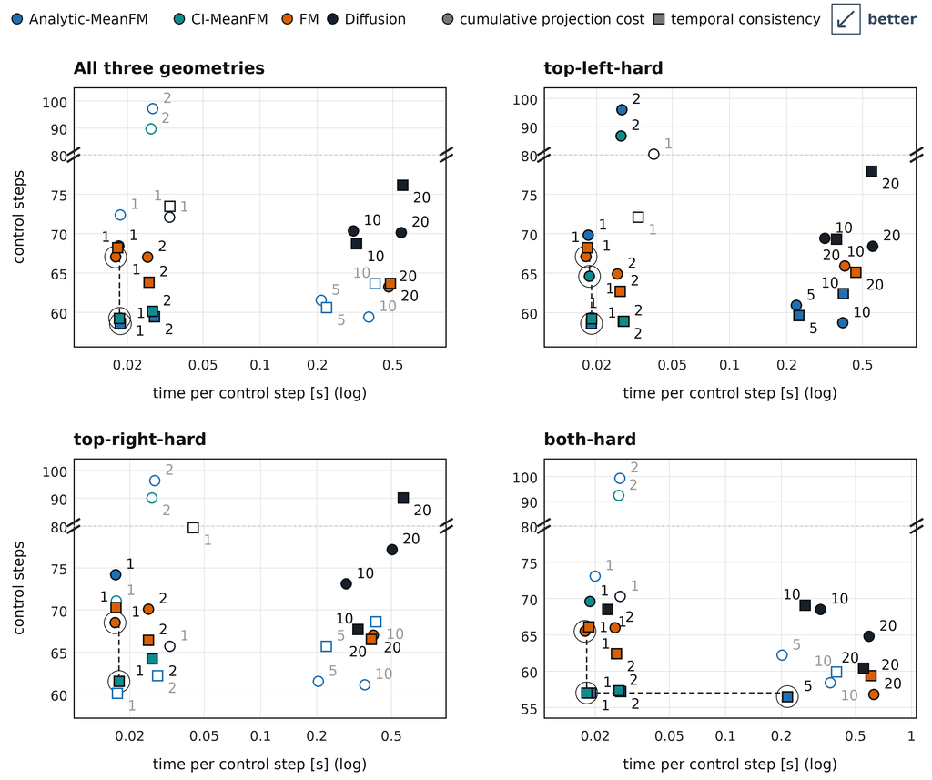

Control steps against time per control step, every budget and selection rule, all three geometries. Thesis Fig. 6.2

## Thesis figure: D3IL-aligning, distance closed against time

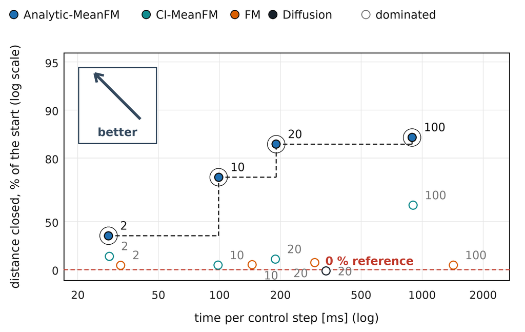

Distance closed against time per control step, every budget, without projection. Thesis Fig. 6.3

## Thesis figure: D3IL-aligning under projection

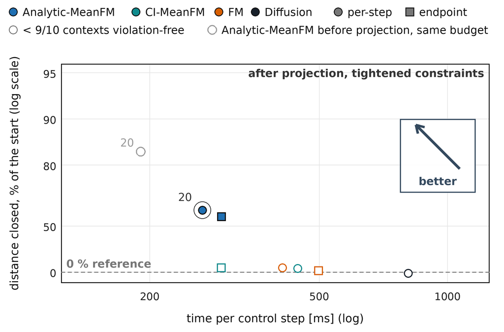

Distance closed against time per control step after projection; circles per-step, squares endpoint; filled points keep at least nine of ten contexts free of violations. Thesis Fig. 6.4

## Thesis figure: UAV-pillars, the flown paths

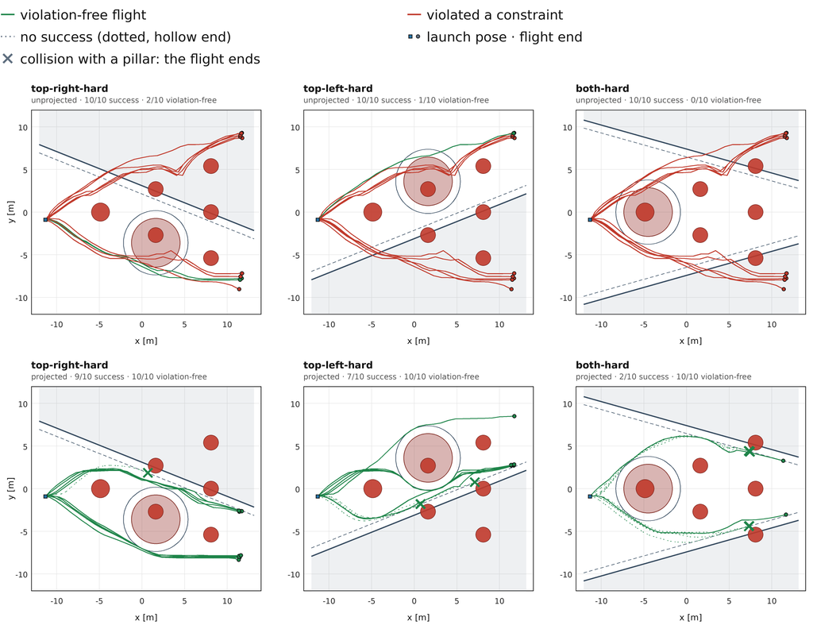

Flown paths, unprojected (top) and projected (bottom), three geometries. Thesis Fig. 6.5

## Thesis figure: UAV-corridor, margin and altitude along the corridor

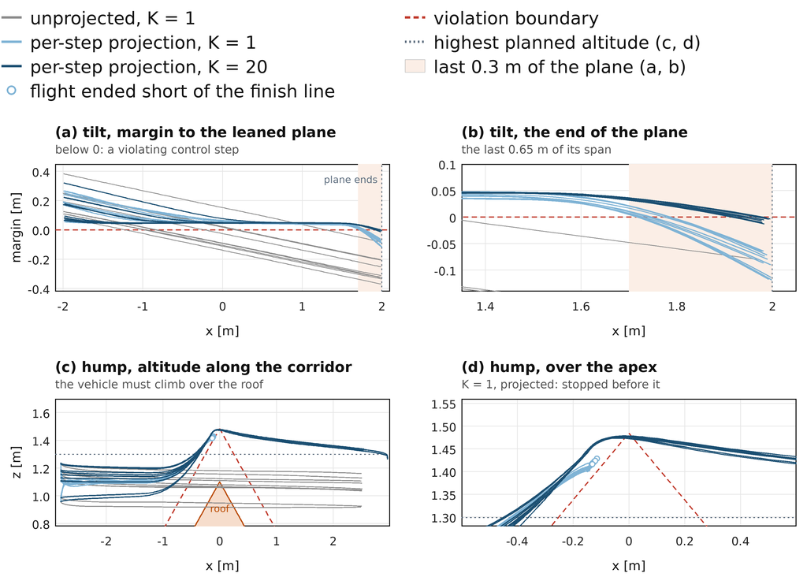

Margin to the tilt and altitude over the hump along the corridor: unprojected, per-step projection at K = 1 and K = 20; panel (d): the K = 1 flight stops before the apex. Thesis Fig. B.4

## Thesis figure: UAV-s-curve, the flown paths

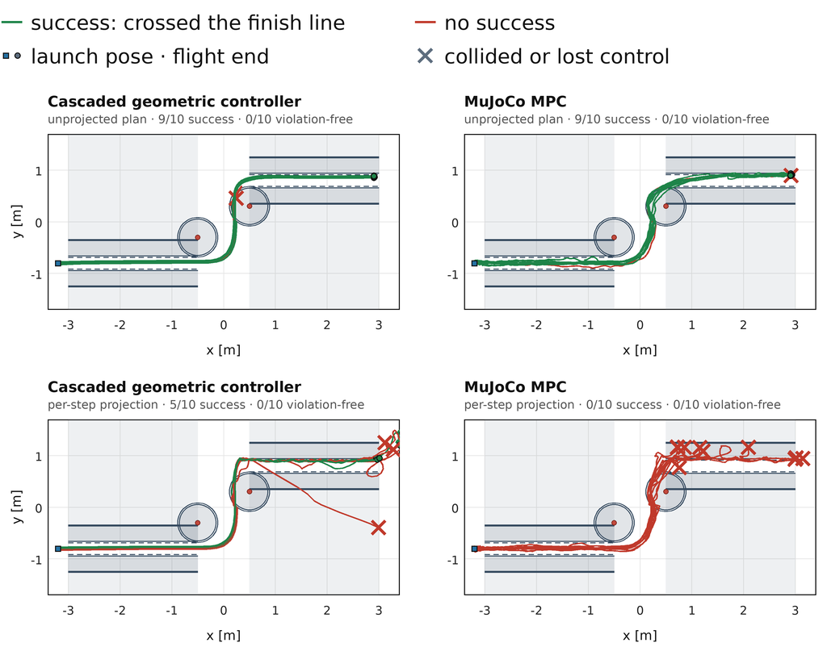

Cascaded geometric controller (left) and MuJoCo MPC (right); unprojected (top) and per-step projection (bottom). Thesis Fig. 6.7